Here I reproduce the plots we have in the slides. They are easily obtained using the package . The crux is to create an object of class containing the event times and whether or not they are censored.

```r
require(survival)
times <- c(1, 3, 3, 6, 8, 9, 10)
status <- c(1, 1, 1, 0, 0, 1, 0)
S <- Surv(times, status)
S
```

```
## [1]  1   3   3   6+  8+  9  10+
```

```r
class(S)
```

```
## [1] "Surv"
```

Note that when we print our object , the censored times appear with a symbol. We can then use the function in order to obtain the Kaplan–Meier estimate of the survival function. Note that implements the approach of slide 17 (based on Greenwood formula).

```r
fit <- survfit(S ~ 1, conf.type = "plain")
fit
```

```
## Call: survfit(formula = S ~ 1, conf.type = "plain")
##
##      n events median 0.95LCL 0.95UCL
## [1,] 7      4      9       3      NA
```

```r
summary(fit)
```

```
## Call: survfit(formula = S ~ 1, conf.type = "plain")
##
##  time n.risk n.event survival std.err lower 95% CI upper 95% CI
##     1      7       1    0.857   0.132        0.598        1.000
##     3      6       2    0.571   0.187        0.205        0.938
##     9      2       1    0.286   0.223        0.000        0.722
```

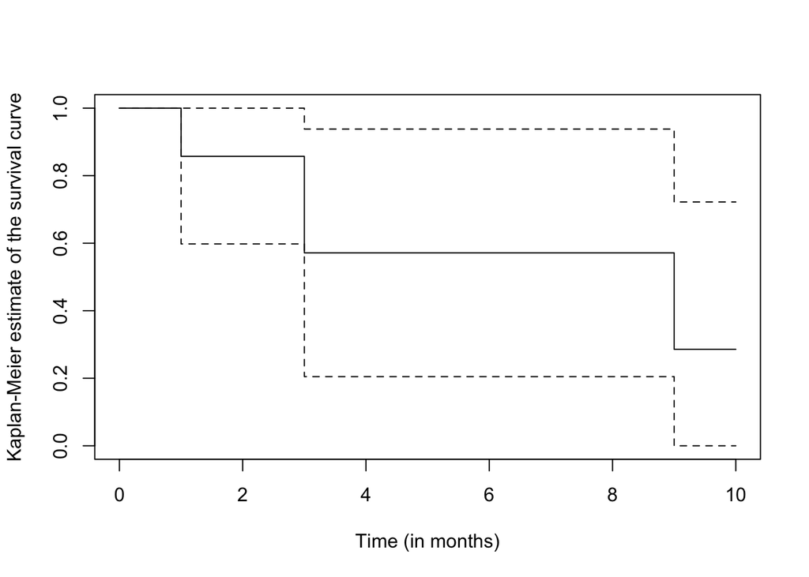

```r
plot(fit,
     xlab = "Time (in months)",
     ylab = "Kaplan-Meier estimate of the survival curve")
```

From the output we can see that the estimated median survival time is 9 (months). Other type of (pointwise) confidence intervals for the survival function can be obtained by changing the argument . A popular approach is to set it to .

```r
fit_alt <- survfit(S ~ 1, conf.type = "log-log")
summary(fit_alt)
```

```
## Call: survfit(formula = S ~ 1, conf.type = "log-log")
##
##  time n.risk n.event survival std.err lower 95% CI upper 95% CI
##     1      7       1    0.857   0.132       0.3341        0.979
##     3      6       2    0.571   0.187       0.1719        0.837
##     9      2       1    0.286   0.223       0.0144        0.691
```

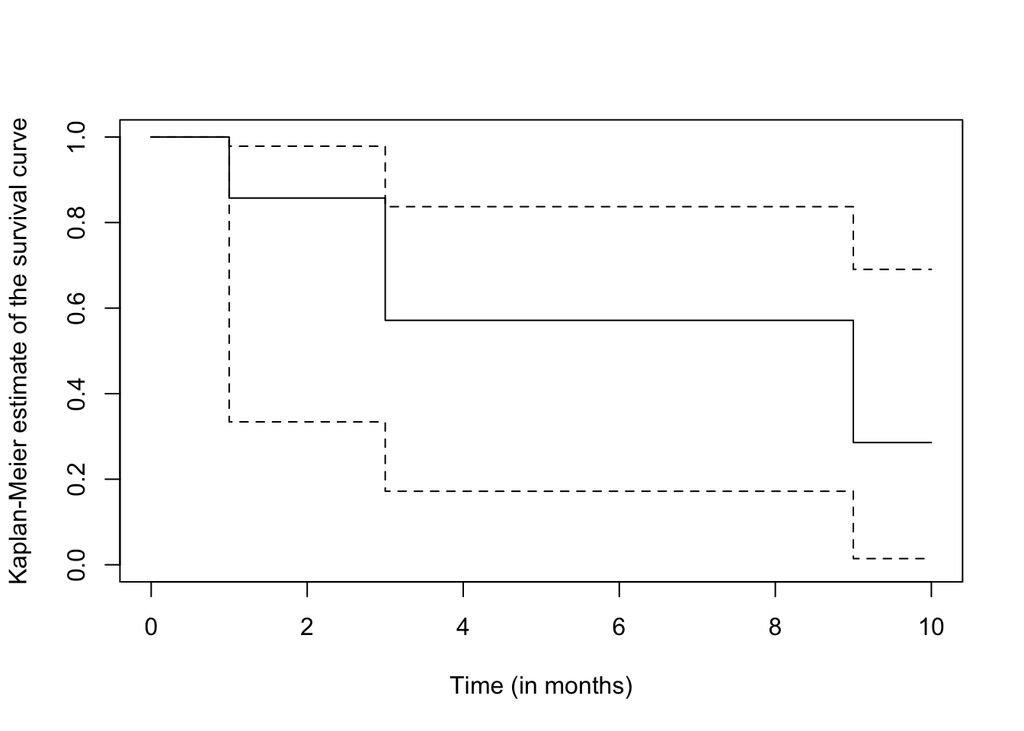

```r
plot(fit_alt,
     xlab = "Time (in months)",
     ylab = "Kaplan-Meier estimate of the survival curve")
```

With regard to the Nelson–Aalen estimate, we proceed exactly in the same way as for the Kaplan–Meier estimate, we just need to specify the following arguments and . More information can be find here:

```r
fit_NA <- survfit(S ~ 1, stype = 2, ctype = 1)
summary(fit_NA)
```

```
## Call: survfit(formula = S ~ 1, stype = 2, ctype = 1)
##
##  time n.risk n.event survival std.err lower 95% CI upper 95% CI
##     1      7       1    0.867   0.124        0.655            1
##     3      6       2    0.621   0.171        0.362            1
##     9      2       1    0.377   0.215        0.123            1
```

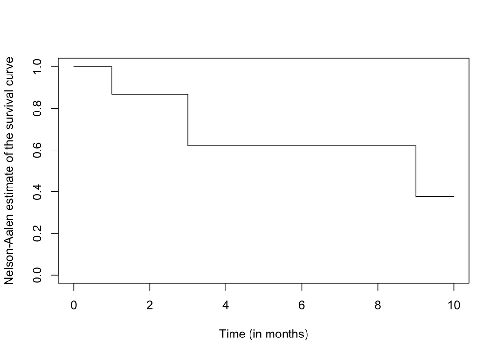

```r
plot(fit_NA, conf.int = FALSE,
     xlab = "Time (in months)",
     ylab = "Nelson-Aalen estimate of the survival curve")
```

Let us visualise both the Kaplan–Meier and the Nelson–Aalen estimates in the same plot.

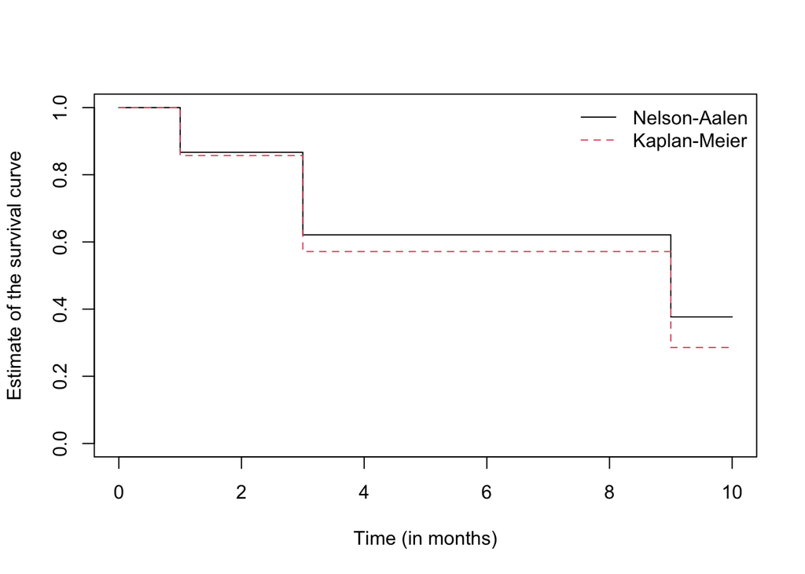

```r
plot(fit_NA, conf.int = FALSE,
     xlab = "Time (in months)",
     ylab = "Estimate of the survival curve")
lines(fit, conf.int = FALSE, col = 2, lty = 2)
legend("topright", lty = c(1, 2), col = c(1, 2),
       c("Nelson-Aalen", "Kaplan-Meier"), bty = "n")
```

A recent package that produces very nice visualisations is .

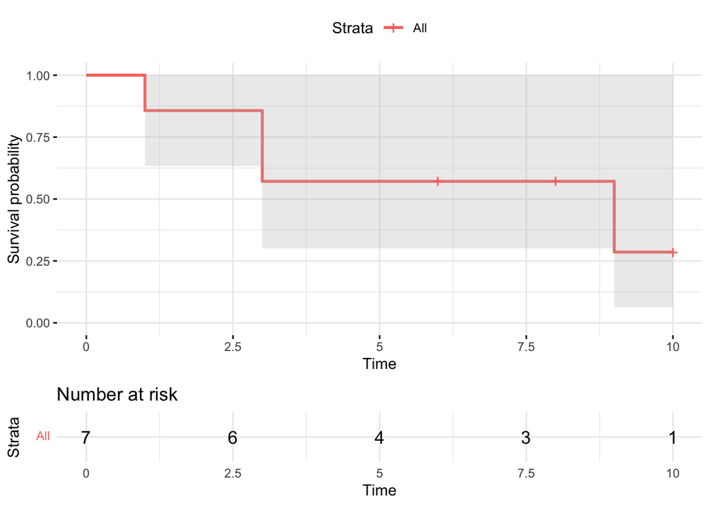

```r
require(survminer)
toy_data <- data.frame("times" = times, "status" = status)
res_fit <- survfit(Surv(times, status) ~ 1, data = toy_data)
ggsurvplot(res_fit,
           conf.int = 0.95,
           ggtheme = theme_minimal(),
           data = toy_data,
           risk.table = TRUE)
```